# Analytathon-3

## Energeia Group - Analysis, Forecasting and Strategy Development

# 1. Abstract

This report aims to represents the taks as follows

- PART 1: Identify the factors resulted in the rise of the I-SEM Day Ahead Price for month July 2021
- PART 2: Develop different Trade stratergies for maximum profit revenue

# 2. PART 1: Data Preprocessing

The Data is provided in an excel sheets and is spread accross different sheets. The data is imported sucessfully and below is quick glimpse on the dimension of all the data to be used for further Analysis

```
Monthy DAM :: (24790, 2)
Hourly DAM :: (24790, 6)
Commodity Prices :: (1004, 7)
Net Demand :: (49392, 10)
Generator Fuel :: (18, 2)
Key generator Availaibility :: (48138, 20)
Key generator Cost :: (18558, 24)
```

The main motive of part 1 is to identify the reason for increase in DAM price for July 2021, To understand this lets get an overview of price trends accross years for varisous commodities. Currently in market there is a high demand for Coal and Gas, used fuel to generate electricity. To Our surprise we see there us a spiked seen in year 2021 with the highest price recorded for both on June 30 2021.

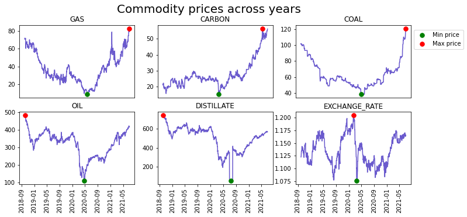

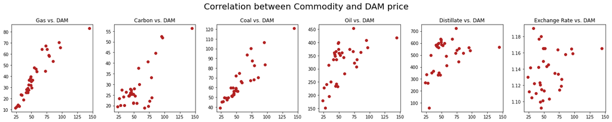

Next focus was to gain some insight on the wind data and see if there are any seasonal patterns occuring. The below plots is created to study hourly and seasonal patterns and below are some of the observations

**Hourly:** There are weak winds during midnight and strong winds observed during day time after 12PM

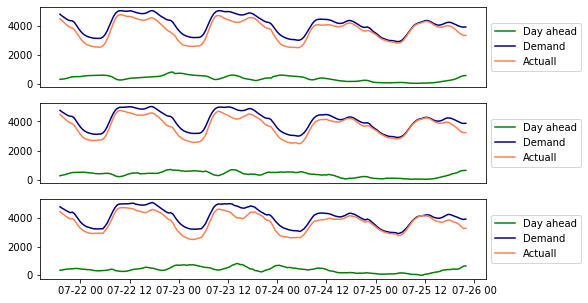

**Seasonal:** We do there are patterns occuring in second plot where the wind is stronger mostly during the winter seasons and wind strength drops during summer, as July and June are the mid of summer months and hence Electricity Generators cannot depends much on wind for electricity generation and look for other commodities.

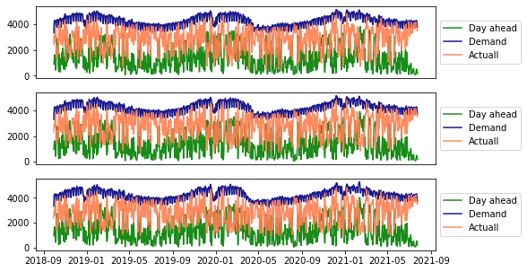

The below table shows that the majority of Generators use Gas as there fuel to produce electricity

| fuel | Generator |
| --- | --- |
| Coal | 5 |
| Gas | 13 |

Generators producing electricity based on the fuel used are as below

```
Coal Generators:: ['GU_400270', 'GU_400271', 'GU_400272', 'GU_500822', 'GU_500823']
Gas Generators:: ['GU_400324', 'GU_400325', 'GU_400480', 'GU_400500', 'GU_400530', 'GU_400540', 'GU_400762', 'GU_400850', 'GU_400930', 'GU_500040', 'GU_500130', 'GU_500131', 'GU_500140']
```

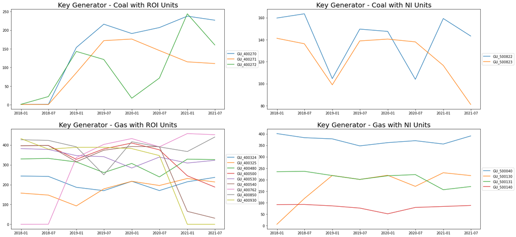

|  | June Price | July Price |
| --- | --- | --- |
| 0 | 69.04 | 72.97 |
| 1 | 66.01 | 71.32 |
| 2 | 65.09 | 68.93 |
| 3 | 69.04 | 72.97 |
| 4 | 78.68 | 85.00 |
| 5 | 78.68 | 85.00 |
| 6 | 84.48 | 88.87 |
| 7 | 50.07 | 54.30 |
| 8 | 179.87 | 207.10 |

# 3. PART 1: Machine Learning model (Vector autoregression)

Below plot is quicK look on how exactly the Coal, Gas and DAM relate. Each of the series have a fairly similar trend patterns over the years

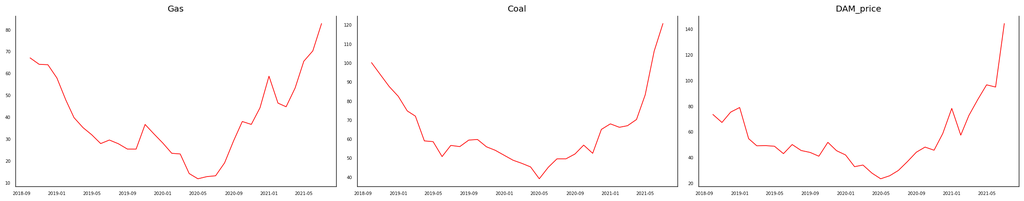

|  | Gas_x | Coal_x | DAM_price_x |
| --- | --- | --- | --- |
| Gas_y | 1.0000 | 0.0110 | 0.0126 |
| Coal_y | 0.1057 | 1.0000 | 0.0002 |
| DAM_price_y | 0.0311 | 0.0001 | 1.0000 |

Cointegration test helps to establish the presence of a statistically significant connection between two or more time series and below are the details

```
Name   ::  Test Stat > C(95%)    =>   Signif
 ----------------------------------------
Gas    ::  44.34     > 24.2761   =>   True
Coal   ::  12.88     > 12.3212   =>   True
DAM_price ::  1.85      > 4.1296    =>   False
```

Check for Stationarity and Make the Time Series Stationary. ADF Test. Augmented Dickey-Fuller Test (ADF Test)

```
    Augmented Dickey-Fuller Test on "Gas"
    -----------------------------------------------
 Null Hypothesis: Data has unit root. Non-Stationary.
 Significance Level    = 0.05
 Test Statistic        = -2.5331
 No. Lags Chosen       = 4
 Critical value 1%     = -3.724
 Critical value 5%     = -2.986
 Critical value 10%    = -2.633
 => P-Value = 0.1076. Weak evidence to reject the Null Hypothesis.
 => Series is Non-Stationary.


    Augmented Dickey-Fuller Test on "Coal"
    -----------------------------------------------
 Null Hypothesis: Data has unit root. Non-Stationary.
 Significance Level    = 0.05
 Test Statistic        = -3.2661
 No. Lags Chosen       = 0
 Critical value 1%     = -3.679
 Critical value 5%     = -2.968
 Critical value 10%    = -2.623
 => P-Value = 0.0165. Rejecting Null Hypothesis.
 => Series is Stationary.


    Augmented Dickey-Fuller Test on "DAM_price"
    -----------------------------------------------
 Null Hypothesis: Data has unit root. Non-Stationary.
 Significance Level    = 0.05
 Test Statistic        = -1.6874
 No. Lags Chosen       = 4
 Critical value 1%     = -3.724
 Critical value 5%     = -2.986
 Critical value 10%    = -2.633
 => P-Value = 0.4376. Weak evidence to reject the Null Hypothesis.
 => Series is Non-Stationary.
```

```
    Augmented Dickey-Fuller Test on "Gas"
    -----------------------------------------------
 Null Hypothesis: Data has unit root. Non-Stationary.
 Significance Level    = 0.05
 Test Statistic        = -3.5248
 No. Lags Chosen       = 8
 Critical value 1%     = -3.833
 Critical value 5%     = -3.031
 Critical value 10%    = -2.656
 => P-Value = 0.0074. Rejecting Null Hypothesis.
 => Series is Stationary.


    Augmented Dickey-Fuller Test on "Coal"
    -----------------------------------------------
 Null Hypothesis: Data has unit root. Non-Stationary.
 Significance Level    = 0.05
 Test Statistic        = -2.9507
 No. Lags Chosen       = 8
 Critical value 1%     = -3.833
 Critical value 5%     = -3.031
 Critical value 10%    = -2.656
 => P-Value = 0.0398. Rejecting Null Hypothesis.
 => Series is Stationary.


    Augmented Dickey-Fuller Test on "DAM_price"
    -----------------------------------------------
 Null Hypothesis: Data has unit root. Non-Stationary.
 Significance Level    = 0.05
 Test Statistic        = -6.5834
 No. Lags Chosen       = 2
 Critical value 1%     = -3.724
 Critical value 5%     = -2.986
 Critical value 10%    = -2.633
 => P-Value = 0.0. Rejecting Null Hypothesis.
 => Series is Stationary.
```

**Training the model with LAG 4 of selected order**

```
  Summary of Regression Results
==================================
Model:                         VAR
Method:                        OLS
Date:           Sun, 08, Aug, 2021
Time:                     01:12:43
--------------------------------------------------------------------
No. of Equations:         3.00000    BIC:                    13.0237
Nobs:                     24.0000    HQIC:                   11.6172
Log likelihood:          -196.476    FPE:                    98559.0
AIC:                      11.1093    Det(Omega_mle):         26898.3
--------------------------------------------------------------------
Results for equation Gas
===============================================================================
                  coefficient       std. error           t-stat            prob
-------------------------------------------------------------------------------
const                0.122477         1.511723            0.081           0.935
L1.Gas              -0.683998         0.652393           -1.048           0.294
L1.Coal              0.177842         0.348584            0.510           0.610
L1.DAM_price         0.068586         0.541670            0.127           0.899
L2.Gas              -1.013498         0.571050           -1.775           0.076
L2.Coal              0.073626         0.458528            0.161           0.872
L2.DAM_price         0.264562         0.493914            0.536           0.592
L3.Gas               0.185863         0.524247            0.355           0.723
L3.Coal              0.711153         0.446166            1.594           0.111
L3.DAM_price        -0.113837         0.438142           -0.260           0.795
L4.Gas              -0.028781         0.473535           -0.061           0.952
L4.Coal              0.707350         0.386499            1.830           0.067
L4.DAM_price         0.258357         0.354492            0.729           0.466
===============================================================================

Results for equation Coal
===============================================================================
                  coefficient       std. error           t-stat            prob
-------------------------------------------------------------------------------
const                0.774424         1.556245            0.498           0.619
L1.Gas               0.040403         0.671607            0.060           0.952
L1.Coal             -0.975773         0.358851           -2.719           0.007
L1.DAM_price         0.080246         0.557623            0.144           0.886
L2.Gas              -0.395257         0.587869           -0.672           0.501
```

[output cut: 19 more lines]

```
L2.Coal             -0.166212         0.658540           -0.252           0.801
L2.DAM_price        -0.440636         0.709363           -0.621           0.534
L3.Gas               0.259075         0.752927            0.344           0.731
L3.Coal              0.609861         0.640786            0.952           0.341
L3.DAM_price        -0.549093         0.629263           -0.873           0.383
L4.Gas              -0.473655         0.680094           -0.696           0.486
L4.Coal              0.634296         0.555092            1.143           0.253
L4.DAM_price         0.308696         0.509123            0.606           0.544
===============================================================================

Correlation matrix of residuals
                  Gas      Coal  DAM_price
Gas          1.000000  0.355854   0.911493
Coal         0.355854  1.000000   0.479120
DAM_price    0.911493  0.479120   1.000000
```

The data is forecasted with Vector Autoregression model and below is the forecast for the test data

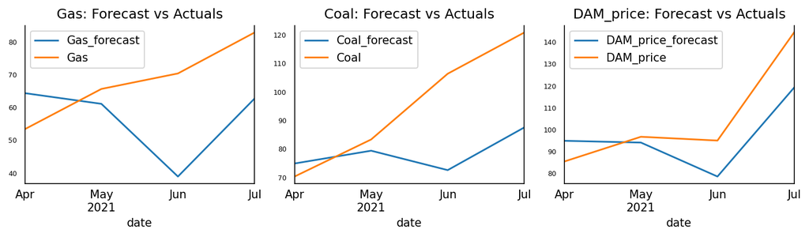

[output not shown]